# Explore_bikeshare_data

### Question 2

**What is the average travel time for users in different cities?**

```r
# Function to display average travel time with different tables as input
find.mean = function(table){
    result = mean(table$Trip.Duration, na.rm = TRUE)
    return(result)
}

# Function to convert seconds to minutes
find.minutes = function(seconds){
    minutes = seconds / 60
    return(minutes)
}
```

```r
# Displaying average travel time for users in New York in minutes

ny.mean = find.mean(ny)
ny.minutes = find.minutes(ny.mean)
paste('New York average travel time:', round(ny.minutes, digits=2), 'minutes')
```

'New York average travel time: 15.06 minutes'

```r
# Displaying average travel time for users in Washington in minutes

wash.mean = find.mean(wash)
wash.minutes = find.minutes(wash.mean)
paste('Washington average travel time:', round(wash.minutes, digits=2), 'minutes')
```

'Washington average travel time: 20.57 minutes'

```r
# Displaying average travel time for users in Chicago in minutes

chi.mean = find.mean(chi)
chi.minutes = find.minutes(chi.mean)
paste('Chicago average travel time:', round(chi.minutes, digits=2), 'minutes')
```

'Chicago average travel time: 15.62 minutes'

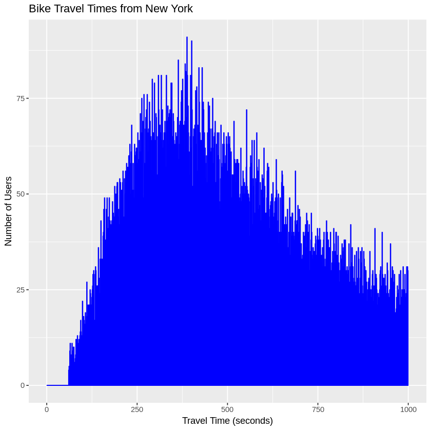

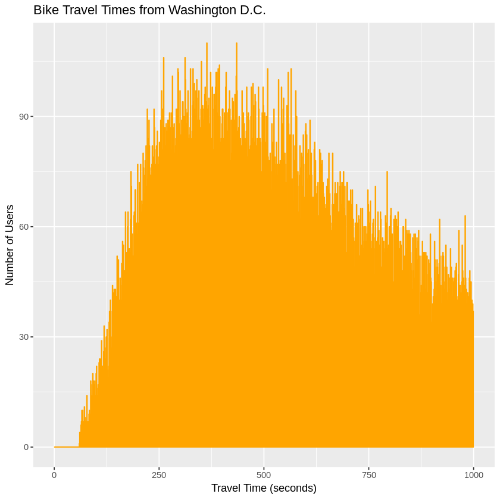

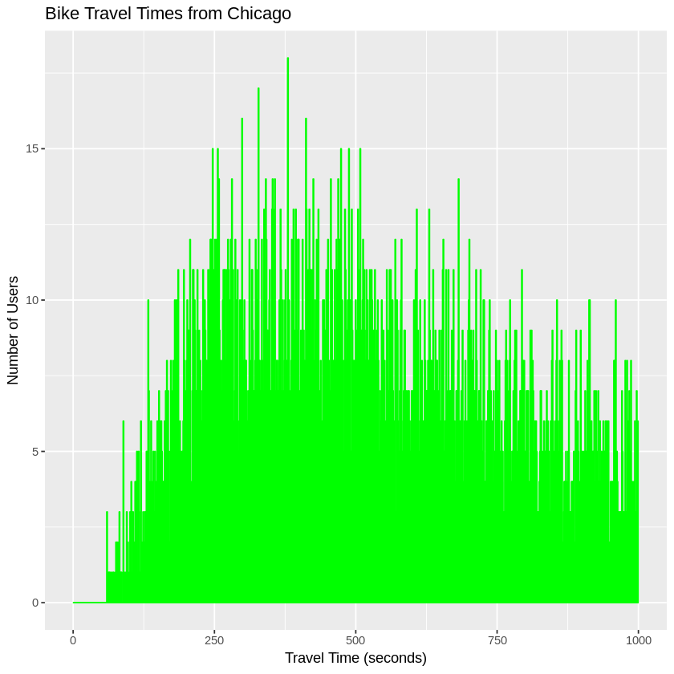

```r
# Plotting the data

# Creating the New York bike travel time graph
ggplot(ny, aes(x = Trip.Duration)) +
  geom_histogram(binwidth=1, color='blue') +
  scale_x_continuous(limits = c(0, 1000)) +
  xlab('Travel Time (seconds)') +
  ylab('Number of Users') +
  ggtitle('Bike Travel Times from New York')

# Creating the Washington D.C. bike travel time graph
ggplot(wash, aes(x = Trip.Duration)) +
  geom_histogram(binwidth=1, color='orange') +
  scale_x_continuous(limits = c(0, 1000)) +
  xlab('Travel Time (seconds)') +
  ylab('Number of Users') +
  ggtitle('Bike Travel Times from Washington D.C.')

# Creating the Chicago bike travel time graph
ggplot(chi, aes(x = Trip.Duration)) +
  geom_histogram(binwidth=1, color='green') +
  scale_x_continuous(limits = c(0, 1000)) +
  xlab('Travel Time (seconds)') +
  ylab('Number of Users') +
  ggtitle('Bike Travel Times from Chicago')
```

### Question 3

**What are the counts of each gender (only available for NYC and Chicago)?**

```r
# Function to return female count
female.count = function(table){
    count = nrow(subset(table, table$Gender == 'Female'))
    return(count)
}

# Function to return male count
male.count = function(table){
    count = nrow(subset(table, table$Gender == 'Male'))
    return(count)
}
```

```r
# Finding the gender counts of New York

ny.females = female.count(ny)
ny.males = male.count(ny)
paste('Number of females in New York table:', ny.females, ', number of males in New York table:', ny.males)
```

'Number of females in New York table: 12159 , number of males in New York table: 37201'

```r
# Finding the gender counts of Chicago

chi.females = female.count(chi)
chi.males = male.count(chi)
paste('Number of females in Chicago table:', chi.females, ', number of males in Chicago table:', chi.males)
```

'Number of females in Chicago table: 1723 , number of males in Chicago table: 5159'

**The numbers of each gender within each city were found through counting the number of rows where gender was equal to either male or female. We can see from the data displayed above that the number of females that rented bikes in New York was 12,159, while the number of males was 37,201. Therefore, we can see that males are more likely to rent a bicycle in New York than females. In Chicago, the number of females that rented a bike was 1,723, while the number of males was 5,159. Chicago also had a greater number of bike rentals from males, however, New York has a higher number of rentals in total.**

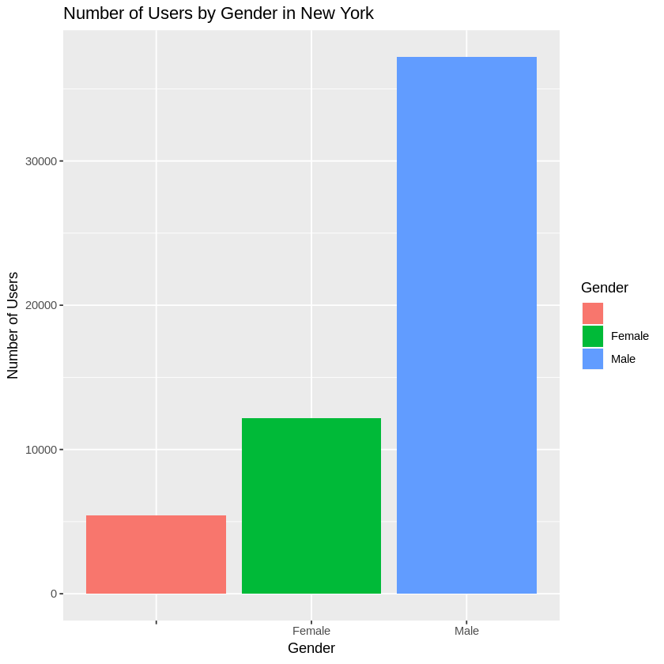

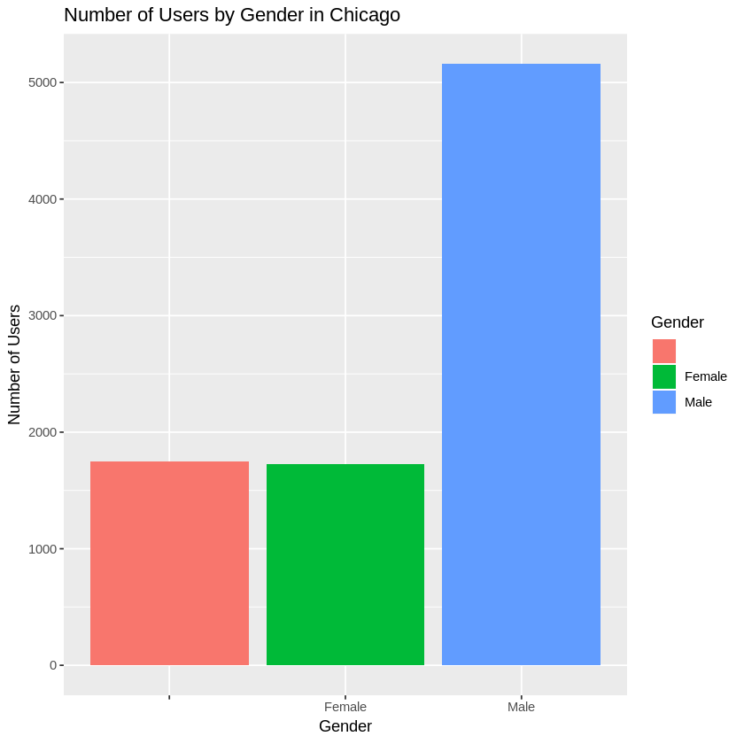

```r
# Plotting the data

# Creating the gender counts graph of New York
ggplot(data=subset(ny, !is.na(Gender)), aes(x = Gender, fill=Gender)) +
  geom_bar() +
  xlab('Gender') +
  ylab('Number of Users') +
  ggtitle('Number of Users by Gender in New York')

# Creating the gender counts graph of Chicago
ggplot(data=subset(chi, !is.na(Gender)), aes(x = Gender, fill=Gender)) +
  geom_bar() +
  xlab('Gender') +
  ylab('Number of Users') +
  ggtitle('Number of Users by Gender in Chicago')
```

## Finishing Up

> Congratulations! You have reached the end of the Explore Bikeshare Data Project. You should be very proud of all you have accomplished!

## Directions to Submit

> Before you submit your project, you need to create a .html or .pdf version of this notebook in the workspace here. To do that, run the code cell below. If it worked correctly, you should get a return code of 0, and you should see the generated .html file in the workspace directory (click on the orange Jupyter icon in the upper left).

> Alternatively, you can download this report as .html via the **File** > **Download as** submenu, and then manually upload it into the workspace directory by clicking on the orange Jupyter icon in the upper left, then using the Upload button.

> Once you've done this, you can submit your project by clicking on the "Submit Project" button in the lower right here. This will create and submit a zip file with this .ipynb doc and the .html or .pdf version you created. Congratulations!

```r
system('python -m nbconvert Explore_bikeshare_data.ipynb')
```